# International migrant stock

Duc-Quang Nguyen | swissinfo.ch

2016

# Text

**Migration series**

Un [rapport de Organisation Internationale pour les Migrations](http://publications.iom.int/system/files/how_the_world_gallup.pdf) (OIM) de 2015 montre que les populations des pays du Golfe malgré leur taux élevé de migrants, ont une opinion favorable de l’immigration. Ces pays dépendent largement de travailleurs étrangers afin de maintenir leur croissance économique, même si des [ONGs](https://www.hrw.org/news/2015/12/22/gulf-countries-bid-protect-migrant-workers) dénoncent régulièrement des abus commis à l’encontre des travailleurs migrants dans ces pays.

Selon ce rapport de l’OIM, ce sont les Européens qui ont l’opinion la plus négative de l’immigration dans le monde, 52% estiment que l’immigration dans leur pays devrait être réduite. Toutefois cet avis varie de manière importante selon les pays, les personnes sondées au Royaume-Uni ainsi que les pays méditerranéens (Grèce, Italie, Espagne, Portugal) souhaitent en majorité une diminuation de l’immigration. Des conclusions à prendre avec des pincettes lorsqu’on voit que l’opinion varie selon le taux de chômage du pays, le niveau d’éducation et l’âge des sondés. Dans ce rapport la Suisse est décrite comme étant favorable à un maintien ou une augmentation de l’immigration, ce qui semble en désaccord avec le résultat des urnes où les Helvètes ont plébiscité de justesse l’imposition de quotas à l’immigration.

## Related stories

- [Economist new divide](http://www.economist.com/news/leaders/21702750-farewell-left-versus-right-contest-matters-now-open-against-closed-new)
- [Telegraph](http://www.telegraph.co.uk/news/worldnews/middleeast/12111108/Mapped-Which-country-has-the-most-immigrants.html)
- [Economist](http://www.economist.com/news/asia/21705376-begrudgingly-japan-beginning-accept-it-needs-more-immigrants-narrow-passage)

## Points

- Heavily reliant on foreign labor to sustain economic growth and high standard of living in the country, the UAE [migrationpolicy](http://www.migrationpolicy.org/article/labor-migration-united-arab-emirates-challenges-and-responses)

```r
txt <- read.csv(translation.file, row.names = 1, stringsAsFactors = F)
# discard incomplete translations
cidx <- unique(which(txt =="" | is.na(txt), T)[,2])
if(length(cidx > 0)) {
  warning(paste(colnames(txt)[cidx], collapse = "\t"), " languages will be discarded!", "\n")
  txt <- txt[,-cidx, drop = F]
}
colnames(txt)
```

```
## [1] "EN" "FR" "DE" "IT" "PT" "AR" "RU" "ES" "ZH"
```

```r
if(getData) {
  getWBdata <- function(db) {
    data.dl  <- WDI(indicator = db, start = 1950, end = 2016,
                    extra = TRUE, cache = NULL)
    colnames(data.dl)[3] <- 'value'
    data.dl$indicator <- db
    data.dl %>% select(-capital, -longitude, -latitude, -lending)
  }
  data <- do.call(rbind, lapply(wb.db, getWBdata))
    write.csv(data, file = data.file, row.names = F)
} else {
  data <- read_csv( file = data.file )
}
```

## Datawrapper world map, export

```r
dw <- data %>% filter(indicator == 'SM.POP.TOTL.ZS') %>%
  select( -income, -indicator) %>%
  rename(pc = value)

dw <- left_join(dw, data %>% filter(indicator == 'SM.POP.TOTL') %>%
  select( -income, -indicator) %>%
  rename(abs = value)
) %>% filter(!is.na(pc)) %>%
  arrange(desc(year))
# discard NA pc and get only the last year
dw  %<>% group_by(iso2c, country, iso3c) %>%
  summarise(
    lastPc = first(pc),
    firstPc = last(pc),
    abs = round(first(abs) / 10^3),
    startYear = last(year)
  ) %>% ungroup()

dw$diffPc <- round(dw$lastPc - dw$firstPc, 1)
dw$diffPc <- ifelse(dw$diffPc >= 0, paste0(" + ", dw$diffPc), dw$diffPc)
dw$lastPc <- round(dw$lastPc, 1)

# append country translations
dw <- cbind(dw, (countryTranslation(as.character(dw$iso3c), c("EN", "DE", "FR", "IT", "ES", "PT","RU", "ZH", "JA","AR")))[,-1])
dw <- dw[!is.na(dw$iso2c),]

dw <- cbind(iso3 = countrycode(dw$iso3c, "wb", "iso3c"), dw)
dw$iso3c <- ifelse(is.na(dw$iso3), as.character(dw$iso3c), as.character(dw$iso3))

write.csv(dw %>% select(-country, -iso3, -firstPc) %>% rename(pc = lastPc), "input/foreignersMap_wb_dw.csv", row.names = F)
```

```r
# discard NA values
data <- filter(data, indicator == 'SM.POP.TOTL.ZS', !is.na(value)) %>% arrange(year)
data$value <- data$value / 100

# find the country with the most changes over time
dd <- data %>% group_by(iso2c,iso3c,country, region) %>%
  summarise(
    deltaPc = last(value) - first(value),
    startT = first(year),
    endT = last(year)
  ) %>% ungroup() %>% arrange(desc(abs(deltaPc)))
dd %>% filter(country == "Switzerland")
```

```
## # A tibble: 1 × 7
##   iso2c iso3c     country                                    region
##   <chr> <chr>       <chr>                                     <chr>
## 1    CH   CHE Switzerland Europe & Central Asia (all income levels)
## # ... with 3 more variables: deltaPc <dbl>, startT <int>, endT <int>
```

```r
#dd %>% as.data.frame() %>% head(20)

# order data by its immigration in the last year
ddd <- data %>% filter(year == 2015) %>% arrange(desc(value))
ddd %>% as.data.frame() %>% head(30)
```

```
##    iso2c                   country     value year iso3c
## 1     AE      United Arab Emirates 0.8840405 2015   ARE
## 2     QA                     Qatar 0.7549763 2015   QAT
## 3     KW                    Kuwait 0.7363955 2015   KWT
## 4     SX Sint Maarten (Dutch part) 0.7044780 2015   SXM
## 5     LI             Liechtenstein 0.6259625 2015   LIE
## 6     AD                   Andorra 0.5971365 2015   AND
## 7     MO          Macao SAR, China 0.5832190 2015   MAC
## 8     VG    British Virgin Islands 0.5746920 2015  <NA>
## 9     MC                    Monaco 0.5576847 2015   MCO
## 10    VI     Virgin Islands (U.S.) 0.5336388 2015   VIR
## 11    IM               Isle of Man 0.5151629 2015   IMN
## 12    BH                   Bahrain 0.5112679 2015   BHR
## 13    JG           Channel Islands 0.5028163 2015   CHI
## 14    SG                 Singapore 0.4539179 2015   SGP
```

[output cut: 78 more lines]

```r
cat("\n", "Switzerland rank of migrant stock in 2015: ")
```

```
##
##  Switzerland rank of migrant stock in 2015:
```

```r
which(ddd$country == "Switzerland")
```

```
## [1] 31
```

```r
dd %>% filter(region == "Aggregates")
```

```
## # A tibble: 19 × 7
##    iso2c iso3c                                      country     region
##    <chr> <chr>                                        <chr>      <chr>
## 1     XD   HIC                                  High income Aggregates
## 2     XC   EMU                                    Euro area Aggregates
## 3     XU   NAC                                North America Aggregates
## 4     EU   EUU                               European Union Aggregates
## 5     S4   OSS                           Other small states Aggregates
## 6     S1   SST                                 Small states Aggregates
## 7     OE   OED                                 OECD members Aggregates
## 8     1A   ARB                                   Arab World Aggregates
## 9     XE   HPC       Heavily indebted poor countries (HIPC) Aggregates
## 10    S3   CSS                       Caribbean small states Aggregates
## 11    XM   LIC                                   Low income Aggregates
## 12    XL   LDC Least developed countries: UN classification Aggregates
## 13    XN   LMC                          Lower middle income Aggregates
## 14    8S   SAS                                   South Asia Aggregates
## 15    1W   WLD                                        World Aggregates
## 16    XO   LMY                          Low & middle income Aggregates
## 17    XP   MIC                                Middle income Aggregates
## 18    S2   PSS                  Pacific island small states Aggregates
## 19    XT   UMC                          Upper middle income Aggregates
## # ... with 3 more variables: deltaPc <dbl>, startT <int>, endT <int>
```

```r
# iso2withN <- unique(data$iso2c)[grep("\\d", unique(data$iso2c))]
# dd[match(iso2withN, dd$iso2c),] %>% as.data.frame()
#
# dd %>% filter(country %in% regions.sub)
```

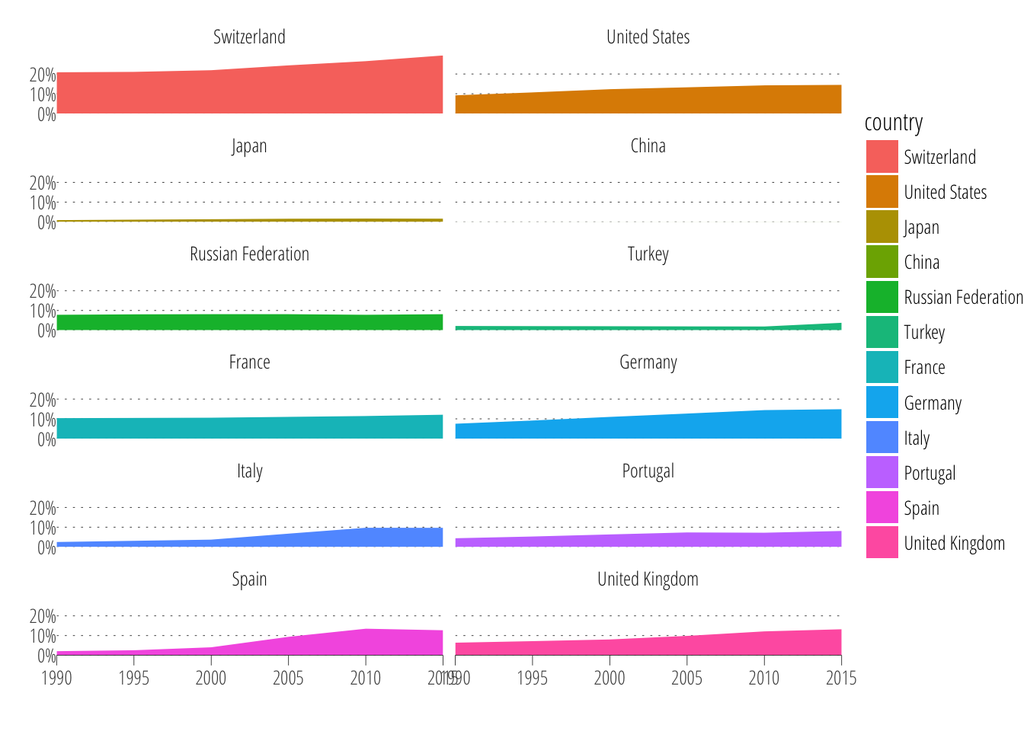

```r
reg.df <- data %>% filter(country %in% countries.sub)

reg.df$country <- factor(reg.df$country, levels = countries.sub)

gp <- ggplot(reg.df) +
  geom_area(aes(year, value, group = country, fill = country)) +
  scale_x_continuous(name = "", expand = c(0,0)) +
  scale_y_continuous(name = "", expand = c(0,0), labels=percent) +
  facet_wrap(~ country, ncol = 2) + swi_theme()
gp
```

```r
# Helper
singleMetricGraphic <- function(df, reg, regions, height = "240px", axis.x = "year", axis.y = "migrants") {
 # browser()
  col <- names(regions)[which(regions == reg)]
  axis.labels <- c( gsub(" ", "_", axis.x), gsub(" ", "_", axis.y))

  dff <- df[which(df$country == reg),]
  colnames(dff)[which(colnames(dff) == "year")] <- axis.labels[1]
  colnames(dff)[which(colnames(dff) == "value")] <- axis.labels[2]

  mjs_plot(data = dff,
           x=axis.labels[1], y = axis.labels[2],
           format="percentage",
           width="100%", height=height,
           decimals = 1,
           left = 28, right = 4, bottom = 20, top = 0, buffer = 0, linked = F,
           title = "") %>%
    mjs_line(area = TRUE, color = col) %>%
    mjs_axis_y(min_y = 0, max_y = max(df$value, na.rm = T)) %>%
    mjs_axis_x(xax_count = 0) %>%
    mjs_labs(x_label = unique(dff$reg))
}

lang <- 'FR'

for(lang in colnames(txt)) {

  reg.df <- data %>% filter(country %in% regions.sub)
  reg.df$reg <- countryTranslation(reg.df$iso2c, lang)[,-1]
  if(any(is.na(reg.df$reg))) stop()

  plots <- lapply(regions.sub, function(reg)
    singleMetricGraphic(reg.df, reg, regions.sub, height = "210px", axis.x = txt["axis.x", lang], axis.y = txt["axis.y", lang])
  )

  reg.df <- data %>% filter(country %in% countries.sub)
  reg.df$reg <- countryTranslation(reg.df$iso2c, lang)[,-1]
  if(any(is.na(reg.df$reg))) stop()

  plots2 <- lapply(countries.sub, function(reg)
    singleMetricGraphic(reg.df, reg, countries.sub, height = "180px", axis.x = txt["axis.x", lang], axis.y = txt["axis.y", lang])
  )

  footer <- paste0(
    txt['source', lang], ": ", htmlLink(txt['source.url', lang], txt['source.name', lang]), " | ",
    txt['code', lang], ": ", htmlLink(txt['code.url', lang], txt['code.name', lang]), " | ",
    htmlLink("http://www.swissinfo.ch", 'swissinfo.ch')
  )

  save_html(
    fluidPage(
      tags$h2(txt['title1', lang]),
      div(class = "descr", txt['desc', lang]),
      div(class="graphic", fluidRow(lapply(1:length(plots), function(i) column(3, plots[[i]])))),
      tags$h2(txt['title2', lang]),
      div(class="graphic", fluidRow(lapply(1:length(plots2), function(i) column(3, plots2[[i]])))),
      div(id = "cite", HTML(footer)),
      HTML(iframeresizer)
    ), file = paste0("02_foreignerBorn_byRegions_", lang,".html"), libdir = "js")

  # overwrite meticgraphics.css by custom version for small multiples using x axis title
  original <- list.files("js", "metricsgraphics.css", full.names = T, recursive = T)
  file.copy(
    list.files(system.file("extdata", package="swiRcharts"), 'metricsgraphics_smallMultiple_xTitles.css', full.names = T),
    original, overwrite = T)
}
```